# Redfish 2013 results

This document summarizes the results of the Redfish 2013 project. For the sake of transparency all relevant code has been included below. Future readers can recreate all of the following results by running the code found in the `/R_code` folder.

The first phase of the Redfish project took place during the late spring and early summer of 2013. This phase of the project involved two separate cruises: Redfish Iceland (RFI) and Redfish German (RFG). RFI sampled the Irminger Sea and RFG sampled the Labrador Sea. Researchers collected chemical data from the upper 100m of the water column. Parameters of particular interest included the carbonate system and macronutrients. Chlorophyll imagery was used to enhance the results of the cruises.

The main objective of Redfish 2013 was to examine inorganic carbon and nutrient dynamics in the Irminger Sea and nearby waters. Researchers involved in the project hoped to establish a baseline for future testing in the study region.

# Data and results

Results from Barkhouse’s work have been recreated. To find the relevant code please refer to the updated directory.

## Redfield drawdown

```r
source('../R_code/00.r')
```

```r
redfield(dataset$C_drawdown,
         dataset$N_drawdown,
         dataset$P_drawdown,
         subset = dataset$Expocode)

kable(redstats1, digits = 2, caption = 'Redfield statistics for RFI')

kable(redstats2, digits = 2, caption = 'Redfield statistics for RFG')
```

Redfield statistics for RFI

| Nutrient Ratio | Mean | Median | Standard deviation |
| --- | --- | --- | --- |
| C:N | 6.38 | 6.44 | 2.16 |
| C:P | 100.07 | 98.97 | 34.38 |
| N:P | 15.71 | 15.33 | 3.06 |

Redfield statistics for RFG

| Nutrient Ratio | Mean | Median | Standard deviation |
| --- | --- | --- | --- |
| C:N | 5.93 | 5.55 | 1.57 |
| C:P | 88.80 | 83.09 | 22.45 |
| N:P | 15.23 | 15.57 | 2.11 |

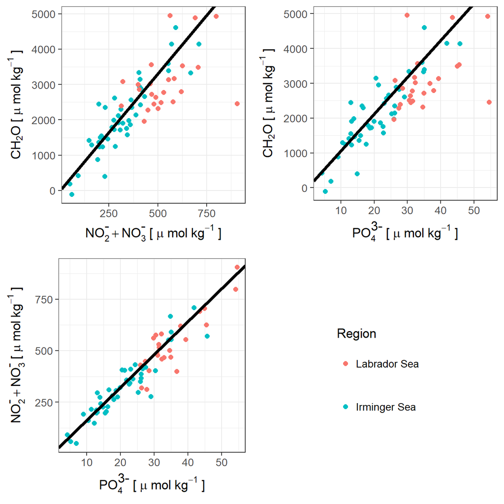

```r
redplot(dataset$C_drawdown,
        dataset$N_drawdown,
        dataset$P_drawdown,
        dataset$Expocode, font.size = 10, size = 1, lwd = 0.75)
```

## Nutrient ranges

```r
nutrientRange(dataset[,10],
              dataset[,15:21],
              depth1 = 0,
              depth2= 15,
              depth3 = 80,
              depth4 = 115)

colnames(ranges1) <- c('Variable','Minimum','Maximum')
colnames(ranges2) <- c('Variable','Minimum','Maximum')

variables <- paste('Alkalinity','pH','Organic carbon',
                  'pCO2','Nitrate','Phosphate','SiO2')
units <- paste('umol/kg','[in-situ]','umol/kg',
              'uatm','umol/kg','umol/kg','umol/kg')

ranges1$Variable <- variables
ranges2$Variable <- variables

ranges1$Units <- units
ranges2$Units <- units

kable(ranges1, digits = 2,
      caption = 'Nutrient ranges in the upper 15 meters of the water column')
kable(ranges2, digits = 2,
      caption = 'Nutrient ranges between 80 and 115 meters')
```

Nutrient ranges in the upper 15 meters of the water column

| Variable | Minimum | Maximum | Units |
| --- | --- | --- | --- |
| Alkalinity | 2194.02 | 2329.74 | umol/kg |
| pH | 8.03 | 8.21 | [in-situ] |
| Organic carbon | 2013.40 | 2150.40 | umol/kg |
| pCO2 | 241.00 | 400.70 | uatm |
| Nitrate | 0.62 | 11.84 | umol/kg |
| Phosphate | 0.17 | 0.78 | umol/kg |
| SiO2 | 0.02 | 9.34 | umol/kg |

Nutrient ranges between 80 and 115 meters

| Variable | Minimum | Maximum | Units |
| --- | --- | --- | --- |
| Alkalinity | 2288.17 | 2331.28 | umol/kg |
| pH | 7.97 | 8.06 | [in-situ] |
| Organic carbon | 2144.60 | 2178.30 | umol/kg |
| pCO2 | 367.80 | 462.30 | uatm |
| Nitrate | 10.32 | 16.95 | umol/kg |
| Phosphate | 0.80 | 1.24 | umol/kg |
| SiO2 | 3.96 | 12.05 | umol/kg |

## Depth profiles

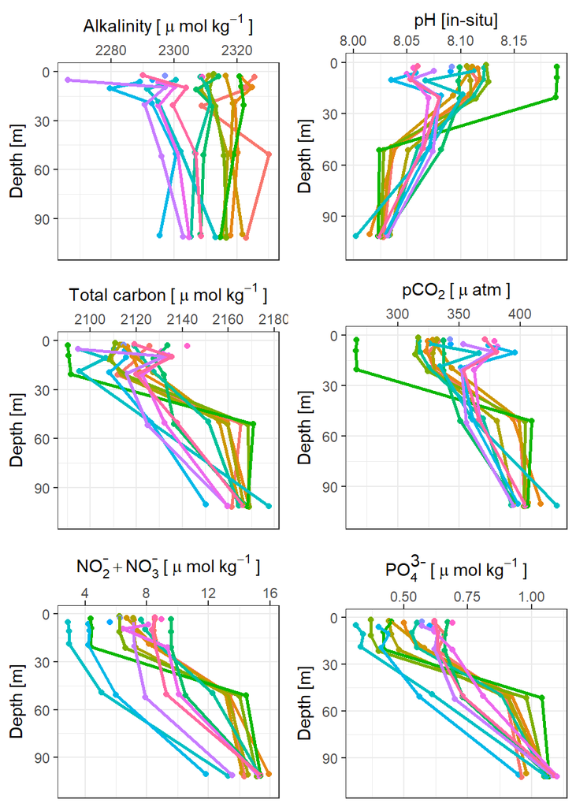

```r
stations <- c(411, 416, 417, 419, 433, 434,
              436, 454, 329, 308, 300, 294,
              291, 269, 251, 244)

generateProfile(dataset[,10],
                 dataset[,15:20],
                 dataset$Station_number,
                 subsets = stations, size = 1.5, lwd=1)

profile1 <- profile1 +
  xlab(expression("Alkalinity"~"["~mu~mol~kg^{-1}~"]"))
profile2 <- profile2 +
  xlab("pH [in-situ]")
profile3 <- profile3 +
  xlab(expression("Total carbon"~"["~mu~mol~kg^{-1}~"]"))
profile4 <- profile4 +
  xlab(expression(pCO[2]~"["~mu~atm~"]"))
profile5 <- profile5 +
  xlab(expression(NO[2]^{{textstyle("-")}}+
                    NO[3]^{{textstyle("-")}}~"["~mu~mol~kg^{-1}~"]"))
profile6 <- profile6 +
  xlab(expression(PO[4]^{{textstyle("3-")}}~"["~mu~mol~kg^{-1}~"]"))

grid.arrange(profile1,profile2,profile3,profile4,profile5,profile6,ncol=2)
```

## Surface plots

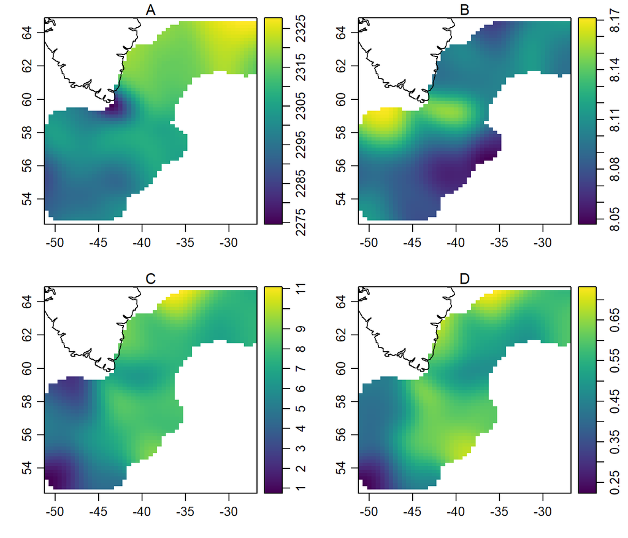

Surface plots of selected measurements in the Redfish 2013 sampling area. A is alkalinity in umol/kg, B is in-situ pH, C is nitrate in umol/kg, and D is phosphate in umol/kg.

```r
par(mfrow=c(2,2))

surfacePlot(dataset$Depth.m.,
            dataset$Latitude,
            dataset$Longitude,
            dataset[,c(15,16,19,20)],
            plot_depth = 10)
```